# Public Policy Analytics Midterm

Charlie Huemmler and Simps Bhebhe

2022-10-16

```r
knitr::opts_chunk$set(echo = TRUE,
  # hides warnings (e.g. WARNING: your code sucks)
  warning=FALSE,

  # hides messages (e.g. doesn't show the results of print("my code sucks"))
  message=FALSE,
  results='hide')
```

```r
library(tidyverse)
library(sf)
library(tidycensus)
library(tigris)
library(corrr)
library(Metrics)
library(modelr)
library(FNN)
library(stargazer)
library(gt)
library(gtsummary)
library(ggthemes)
library(paletteer)
library(ggridges)
library(caret)
library(spdep)
library(knitr)
library(sjPlot)


sf_use_s2(FALSE)
options(tigris_use_cache = TRUE)
options(scipen = 999)


source("https://raw.githubusercontent.com/urbanSpatial/Public-Policy-Analytics-Landing/master/functions.r")
census_api_key("746ea8916547306ae2abf2aafe059e1a1b70b98a", overwrite = TRUE)
```

```r
homesales <- read_sf('https://raw.githubusercontent.com/mafichman/MUSA_508_Lab/main/Midterm/data/2022/studentData.geojson')

water <- area_water( state='North Carolina', county='Mecklenburg') %>%   st_transform(st_crs(homesales))


char.census <- get_acs(geography = "tract",
                       variables = c("B25026_001E"),
                       year=2020, state='North Carolina', county='Mecklenburg',
                       geometry=TRUE, output="wide") %>%
  st_transform(st_crs(homesales)) %>%
  rename(TotalPop = B25026_001E,
         ) %>%
  dplyr::select(-NAME, -starts_with("B"))

#load spatial ammenities

highschools <- read_sf('C:/Users/cchue/Documents/Penn MUSA/Public Policy Analytics/Midterm/SchoolBoundary_High.shp')%>%
  st_transform(st_crs(homesales))

parks <- read_sf('C:/Users/cchue/Documents/Penn MUSA/Public Policy Analytics/Midterm/ParkAmenity.shp')%>%
  st_transform(st_crs(homesales)) %>% st_zm()

#http://maps.co.mecklenburg.nc.us/opendata/metadata/Neighborhood_Profile_Areas.xml
nbhoods <- read_sf('C:/Users/cchue/Documents/Penn MUSA/Public Policy Analytics/Midterm/npa.shp')%>%
  st_transform(st_crs(homesales))

homesales <- homesales %>% st_join(highschools)

homesales <-
  homesales %>%
  mutate(parks_nn3 = nn_function(st_coordinates(homesales),
                            st_coordinates(parks %>% filter(amentype == 'PLAYGROUND')), k = 3))

homesales <- homesales %>% st_join(nbhoods)
```

## Introduction

```r
#modelling


inputdf.geom <- homesales %>% filter(toPredict != 'CHALLENGE') %>%
  dplyr::select(price, bedrooms, extwall, heatedarea, actype, numfirepla, bldggrade, fullbaths, HIGH_NAME, parks_nn3, musaID) %>%
  na.omit()

inputdf <- inputdf.geom %>%  st_drop_geometry()
##logging price

inputdf$lnprice <- inputdf$price %>% log()
###remove outliers

inputdf <- inputdf %>% filter(price < 10000000)
inputdf <- inputdf %>% filter(bedrooms < 40)



#create model
inTrain <- createDataPartition(
  y = paste(inputdf$extwall, inputdf$actype),
  p = .60, list = FALSE)

inputdf.train <- inputdf[inTrain,]
inputdf.test <- inputdf[-inTrain,]


model_train <- lm(lnprice ~ ., data = inputdf.train %>% select(-price, -musaID))


competition <- homesales %>% st_drop_geometry() %>%
  add_predictions(model_train) %>%
  filter(toPredict == 'CHALLENGE') %>% select(musaID, pred)
```

## Data

For the numeric variables we use in our regression we considered these four variables:

- number of bedrooms (bedrooms)
- number of fireplaces (numfirepla)
- heated area (heatedarea)
- full bathrooms (full baths = bathrooms with washing apparatus, toilet and sink).

Lastly, we utilized park amenities data which was retrieved from Mecklenburg’s open data portal. By measuring the average distance to the three nearest playgrounds from a home we were able to create variable parks_nn3. This concluded the numeric variables in our table. Additionally, we collected the school district boundaries data to see if the school catchment areas impacted house value. This formed part of our categorical variables. Our categorial variables included inputs such as:

- Exterior Walls (extwalls = what material of the wall is made of)
- has AC (actype)
- Condition of the building (bldggrade)
- High School (HIGH_NAME)

We have omitted the summary table of the categorical variables in this portion of the report, but later in this report we will show the beta coefficients of each variable used in our regression model.

Summary

```r
sdf <- as.data.frame(apply(inputdf %>%  dplyr::select(price, bedrooms, numfirepla, fullbaths, parks_nn3), 2, summary)) %>%
  t() %>% as.data.frame() %>% round(digits = 2) %>%
  mutate(variable = row.names(.))

sdf$sd <- c(sd(inputdf$price), sd(inputdf$bedrooms), sd(inputdf$numfirepla),sd(inputdf$fullbaths), sd(inputdf$parks_nn3)) %>% round(2)

sdf %>% gt() %>%
  cols_move_to_start(variable) %>%
  tab_row_group(
    label = "Predictors - Amenity",
    rows = c(5))%>%
  tab_row_group(
    label = "Predictors - Internal",
    rows = c(2:4)) %>%
  tab_row_group(
    label = "Target",
    rows = c(1))  %>%
  tab_header(
    title = "Numeric variable summary table",
    subtitle = ""
  )
```

Numeric variable summary table

| variable | Min. | 1st Qu. | Median | Mean | 3rd Qu. | Max. | sd |
| --- | --- | --- | --- | --- | --- | --- | --- |
| Target |  |  |  |  |  |  |  |
| price | 12000 | 283000.00 | 368000.00 | 461526.53 | 507500.00 | 7700000.00 | 371629.07 |
| Predictors - Internal |  |  |  |  |  |  |  |
| bedrooms | 0 | 3.00 | 3.00 | 3.51 | 4.00 | 9.00 | 0.84 |
| numfirepla | 0 | 1.00 | 1.00 | 0.79 | 1.00 | 7.00 | 0.47 |
| fullbaths | 0 | 2.00 | 2.00 | 2.28 | 3.00 | 9.00 | 0.82 |
| Predictors - Amenity |  |  |  |  |  |  |  |
| parks_nn3 | 0 | 0.01 | 0.02 | 0.02 | 0.03 | 0.08 | 0.01 |

### Figure 1: Correlation matrix

To show the impact a variable in our model has on home price we made a correlation matrix. We utilized the Pearson correlation matrix which ranges between 1 and -1. The further away the correlation coefficient is from zero, the stronger the relationship between the two variables.

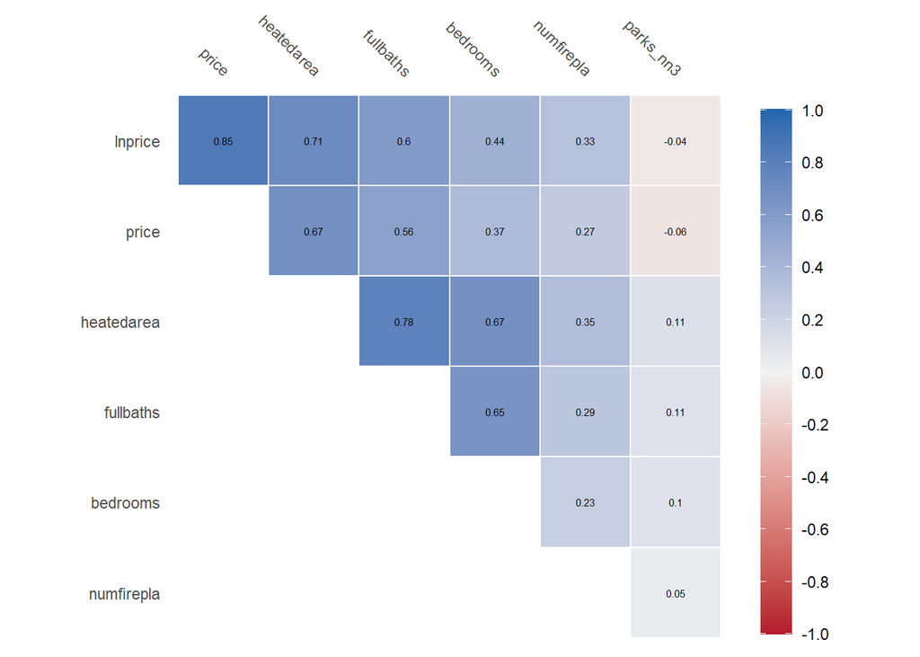

```r
inputdf %>% select(-musaID) %>%
  correlate() %>%
  autoplot() +
  geom_text(aes(label = round(r,digits=2)),size = 2)
```

### Figure 2: Correlation Scatterplots

For the 4 home price correlation scatterplots we looked at the following predictor variables: number of bedrooms (# of bedrooms: top-left); number of fireplaces (# of fireplaces: top-right); heated area (sq. ft.): bottom left; average distance to nearest 3 playgrounds (avg distance to nearest 3 playgrounds: bottom-right). Heated area has the greatest impact on price followed by number of bedrooms. Followed by the number of fireplaces. The average distance to the nearest 3 playgrounds has the weakest impact on price in comparison with these other aforementioned predictors.

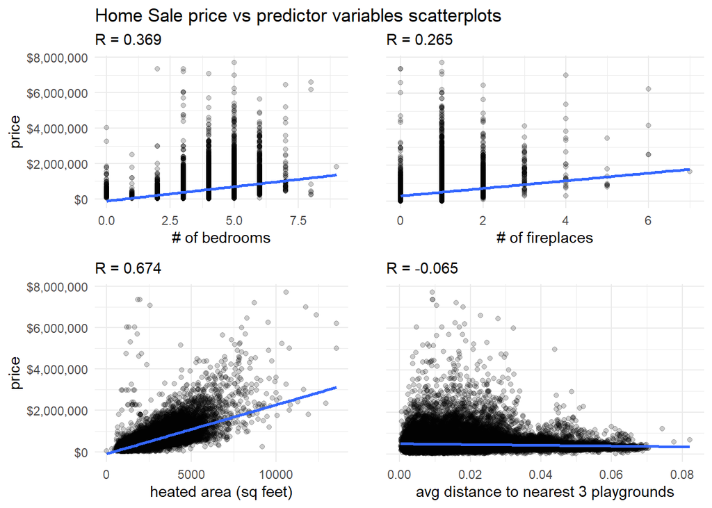

```r
p1 <- ggplot(inputdf)+
  geom_point(aes( y = price, x = bedrooms), alpha = .2)+
  geom_smooth(aes( y = price, x = bedrooms),method = 'lm', se = F)+
  theme_minimal()+
  labs(x = '# of bedrooms', title = 'Home Sale price vs predictor variables scatterplots', subtitle = paste('R =', cor(y = inputdf$price, x = inputdf$bedrooms) %>% round(3)))+
  scale_y_continuous(labels = scales::dollar_format())


p2 <- ggplot(inputdf)+
  geom_point(aes( y = price, x = numfirepla), alpha = .2)+
  geom_smooth(aes( y = price, x = numfirepla),method = 'lm', se = F)+

  theme_minimal()+
  theme(axis.text.y=element_blank())+
  labs(x = '# of fireplaces', y = '', title ='', subtitle = paste('R =', cor(y = inputdf$price, x = inputdf$numfirepla) %>% round(3)))+

  scale_y_continuous(labels = scales::dollar_format())


p3 <- ggplot(inputdf)+
  geom_point(aes( y = price, x = heatedarea), alpha = .2)+
  geom_smooth(aes( y = price, x = heatedarea),method = 'lm', se = F)+

  theme_minimal()+
  labs(x = 'heated area (sq feet)', subtitle = paste('R =', cor(y = inputdf$price, x = inputdf$heatedarea) %>% round(3)))+

  scale_y_continuous(labels = scales::dollar_format())



p4 <- ggplot(inputdf)+
  geom_point(aes( y = price, x = parks_nn3), alpha = .2)+
  geom_smooth(aes( y = price, x = parks_nn3),method = 'lm', se = F)+

  theme_minimal()+
  labs(x = 'avg distance to nearest 3 playgrounds', y = '', subtitle = paste('R =', cor(y = inputdf$price, x = inputdf$parks_nn3) %>% round(3)))+
  theme(axis.text.y=element_blank())+
  scale_y_continuous(labels = scales::dollar_format())



cowplot::plot_grid(p1, p2, p3, p4, ncol = 2)
```

### Figure 3: Dependent variable (sale price)

On this map we are seeing clustering of high-value homes. We have been able to identify concentrations of wealth in Mecklenburg County. The wedge south of Downtown Charlotte has the highest concentration of high-priced homes. Additionally, there are high-priced homes in the area far north of Downtown Charlotte (near the Mecklenburg County boarder by lake Norman). The last notable cluster of high-priced homes is in the far southwestern area on the boarder. The moderately priced homes are located in the central parts of Mecklenburg north of Downtown Charlotte.

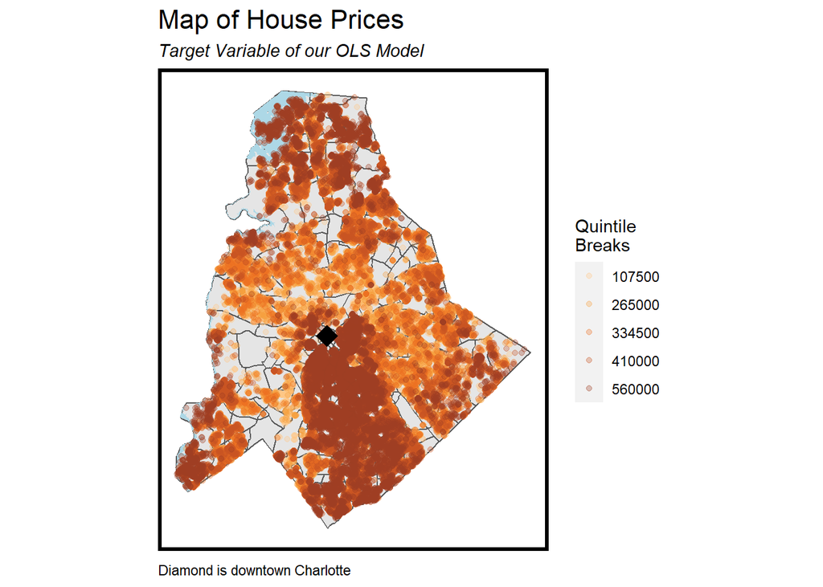

```r
ggplot(inputdf.geom)+
  geom_sf(data = char.census)+
  geom_sf(data = water %>% filter(AWATER > 500000), fill = 'lightblue', color = NA)+
  geom_sf(aes(color = q5(price)), alpha = .3)+
  scale_colour_manual(values = paletteer_c("ggthemes::Orange", 5),
                      labels=qBr(inputdf.geom,"price"),
                      name="Quintile\nBreaks")+
  mapTheme()+
  geom_point(y = 35.22721359696115, x = -80.84203989097965, shape = 18, size = 6)+
  labs(title = 'Map of House Prices', subtitle = 'Target Variable of our OLS Model', caption = 'Diamond is downtown Charlotte')
```

### Figure 4: 3 maps of 3 Interesting Independent Variables

[figure not shown]

```r
statsig_walltypes <- summary(model_train)$coefficients %>% as.data.frame() %>% filter( rownames(.) %>% grepl(pattern = 'extwall',.)) %>%
  filter(`Pr(>|t|)` > .05 ) %>% rownames() %>% substr(start = 8,stop = nchar(.))

sswt <- homesales[which(homesales$extwall %in% statsig_walltypes),]


wallyear <- homesales %>% st_drop_geometry() %>% select(extwall, yearbuilt) %>%
  group_by(extwall, yearbuilt) %>%
  summarise(count = n()) %>%  na.omit()

#perhaps a cool thing
ggplot(wallyear %>% filter(yearbuilt > 1875))+
  geom_density_ridges(stat = "identity", aes(height = count, y = reorder(extwall, count), x = yearbuilt, fill = extwall %in% statsig_walltypes, color= extwall %in% statsig_walltypes))+
  theme_minimal()+
  scale_color_discrete(guide = 'none')+
  labs(fill = 'Statistically Significant in Model?', color = "", y = 'Exterior Wall Type', x= 'Year Built', title = 'Construction Timeline of each Wall Type')
```

[figure not shown]

```r
ggplot(sswt)+
  geom_sf(data = char.census)+
  geom_sf(data = water %>% filter(AWATER > 500000), fill = 'lightblue',color = NA)+
  geom_sf(aes(color = extwall), alpha = .7)+
  labs(title = 'Map of Statisically Significant Wall Types')+
  mapTheme()
```

Map2: Each building is assigned a grade based on the condition of the building. We map out where these buildings are and their average home value. It is interesting to see that the home grade custom is in the higher home value areas like the wedge and in the homes by Lake Norman.

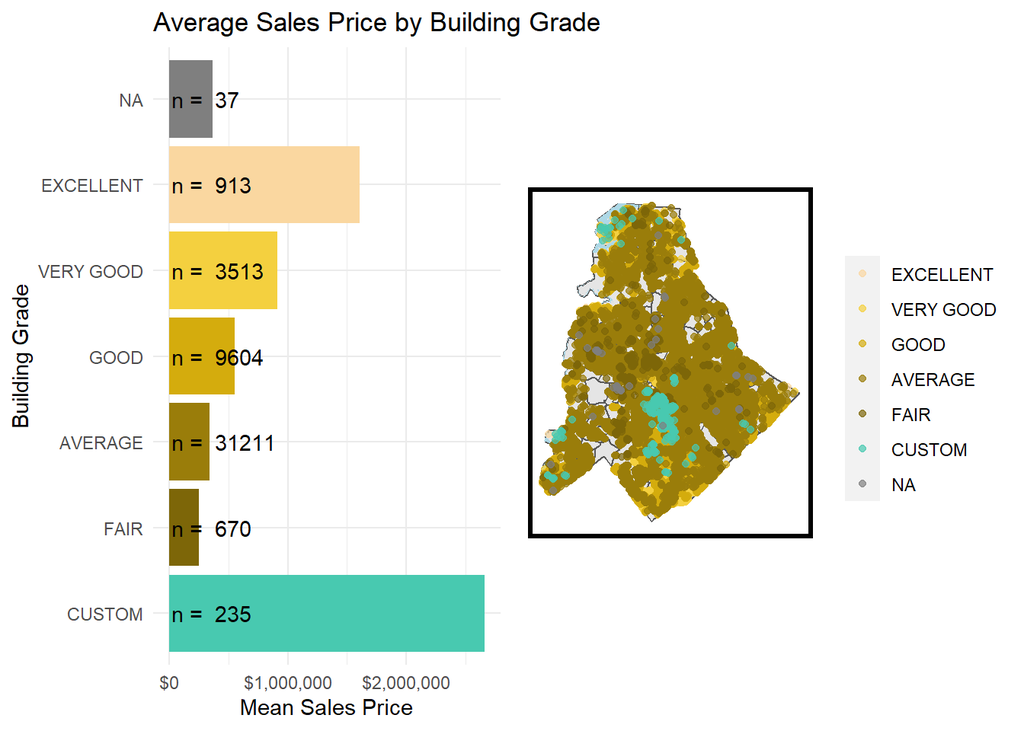

```r
homesales$bldggrade <- homesales$bldggrade %>% factor(levels = c('EXCELLENT', 'VERY GOOD', 'GOOD', 'AVERAGE', 'FAIR', "MINUMUM", 'CUSTOM'))

bldgtab <- homesales %>%  st_drop_geometry() %>%  group_by(bldggrade) %>%
  summarize(count = n(), mean = mean(price))


bldg1<-ggplot(bldgtab)+
  geom_bar(aes(x = reorder(bldggrade, desc(bldggrade)), fill = reorder(bldggrade, desc(bldggrade)), y = mean), stat = 'identity')+
  geom_text(aes(x = reorder(bldggrade, desc(bldggrade)),label = paste('n = ',count)), y = 20000, hjust = 0)+
  scale_fill_manual(values = c('#48C9B0','#7D6608','#9A7D0A','#D4AC0D','#F4D03F', '#FAD7A0'))+
  coord_flip()+
  theme_minimal()+
  theme(legend.position = 'none')+
  scale_y_continuous(labels = scales::dollar_format())+
  labs(x = 'Building Grade', y = 'Mean Sales Price', title = 'Average Sales Price by Building Grade')

bldg2<-ggplot(homesales)+
  geom_sf(data = char.census)+
  geom_sf(data = water %>% filter(AWATER > 500000), fill = 'lightblue',color = NA)+
  geom_sf(aes(color = bldggrade), alpha = .7)+
  scale_color_manual(values = c('#FAD7A0','#F4D03F','#D4AC0D','#9A7D0A','#7D6608','#48C9B0'))+
  labs(color = '')+
  mapTheme()

cowplot::plot_grid(bldg1, bldg2)
```

```r
#map3
```

Map3: Looks at median home values by school district. This Map shows the prices of homes in the school districts of Mecklenburg County. Continuing with the trend of higher value homes in the wedge and in the lake Norman. However, we find a greater breakdown of the wealth clusters by school district. The northern part of the wedge directly south of Charlotte is clearly the most affluent area in Mecklenburg County.

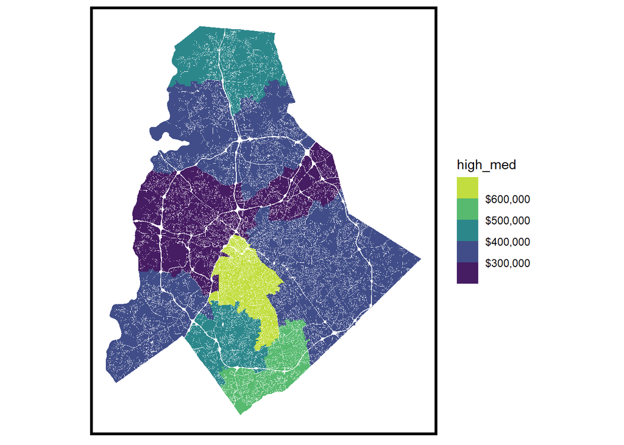

```r
#left to reader as an excercise
homesales %>% group_by(HIGH_NAME) %>% summarise(high_med = median(price)) %>% st_drop_geometry() %>% left_join(highschools ,.) %>%
  ggplot()+
  geom_sf(aes(fill = high_med), color = NA)+
  scale_fill_viridis_b(labels = scales::dollar_format())+
  mapTheme()
```

## Methods

The modelling technique used for this analysis is linear regression. Our target variable is home sale price which we logarithmically transformed to make more normally distributed. We removed outlier observations where home values were greater than $10,000,000.00 and the number of bedrooms were greater than 40. To select our predictor variables we looked through the provided data set and considering the predictive power of each, we determined which variables to include. We did this by using our intuition (trial and error) and limited understanding of home evaluation. Furthermore using Mecklenburg’s open data portal we included variables of school districts and average distance to three nearest playgrounds.

We created a 60/40 training-test split to analyze our models predictive power. We did this by calculating the effect each independent variable has on the target variable (training set). And then we took this model and we ran it on the test set. By analyzing the difference between our predictive values and actual values of sale price we can judge the model. We put 60% of the data in the training set and 40% in the test set.

Finally we ran a cross validation test on the model. Creating 100 folds in which we tested the model on a hold out group. A hold out group is one one hundredth of the data that is the test set for that fold.

## Results

Our model has a Mean Absolute Percent Error of 0.0164, meaning on average, our model erred by 1.64% when predicting home prices. Furthermore the R-squared is 0.69 which means the model accounts for 69% of the variation in the home sale price.

```r
inputdf.test <-
  inputdf.test %>%
  mutate(SalePrice.Predict = predict(model_train, inputdf.test),
         SalePrice.Error = SalePrice.Predict - lnprice,
         SalePrice.AbsError = abs(SalePrice.Predict - lnprice),
         SalePrice.APE = (abs(SalePrice.Predict - lnprice)) / SalePrice.Predict)

#Provide a polished table of mean absolute error and MAPE for a single test set. Check out the “kable” function for markdown to create nice tables.


modelmae <- mae(model_train, inputdf.test) %>% round(digits = 4)
modelmape <- mape(model_train, inputdf.test) %>% round(digits = 4)

modeltab <- as.data.frame(modelmae)
modeltab$mape <- modelmape

modelattr <- model_train %>%  summary() %>% attributes()

modeltab$r2 <- summary(model_train)$r.squared %>% round(digits = 4)
modeltab$adjr2 <- summary(model_train)$adj.r.squared %>% round(digits = 4)

modeltab$fstat <- summary(model_train)$fstatistic[1] %>% round(digits = 4)

modeltab$test <- '1'

modeltab %>% gt() %>%
  cols_move_to_start(test) %>%
  tab_header(
    title = "Model Summary statistics") %>%
  cols_label(modelmae = 'Mean Absolute Error',
             mape = 'Mean Absolute % Error',
             r2 = "R^2",
             adjr2 = 'Adjusted R^2',
             fstat = 'F-Statistic',
             test = 'Model #')
```

[output not shown]

### Impact of predictor variables on price

Below is the list of the predictor variables that we included in the model with their beta coefficients. The beta coefficient refers to the percent change in the target variable when the predictor variable changes by 1 unit. Furthermore the p-value refers to whether the value of the coefficient is statistically different from zero. A p-value less than 0.05 will indicate that this is the case.

```r
table2 <- broom::tidy(model_train) %>%
  mutate(
    p.value = scales::pvalue(p.value),
  ) %>% kable(
    caption = "Predictor List",
    col.names = c("Predictor", "Beta coeffient", "standard error", "t-value", "p-value"),
    digits = c(0, 2, 3, 2, 4),
    align = c("l", "r", "r", "r", "r")
  )
table2
```

Predictor List

| Predictor | Beta coeffient | standard error | t-value | p-value |
| --- | --- | --- | --- | --- |
| (Intercept) | 12.25 | 0.014 | 846.89 | <0.001 |
| bedrooms | -0.01 | 0.003 | -4.10 | <0.001 |
| extwallASB SHNG/SDG | -0.08 | 0.031 | -2.46 | 0.014 |
| extwallBOARD&BATTEN | 0.20 | 0.063 | 3.11 | 0.002 |
| extwallCEDAR,RDWD | 0.18 | 0.019 | 9.12 | <0.001 |
| extwallCEM BR/SPL B | 0.02 | 0.068 | 0.34 | 0.734 |
| extwallCOMP OR WLBD | -0.08 | 0.151 | -0.54 | 0.588 |
| extwallCONC BLOCK | -0.19 | 0.066 | -2.93 | 0.003 |
| extwallCORR MTL LGT | -0.06 | 0.213 | -0.27 | 0.788 |
| extwallEXT PLYWOOD | -0.03 | 0.032 | -0.80 | 0.425 |
| extwallFACE BRICK | 0.02 | 0.005 | 4.31 | <0.001 |
| extwallHARDIPLK/DSGN VINYL | 0.08 | 0.006 | 12.73 | <0.001 |
| extwallIMITATION STONE | 0.31 | 0.213 | 1.46 | 0.145 |
| extwallLOG | 0.24 | 0.101 | 2.37 | 0.018 |
| extwallMASONITE | -0.01 | 0.007 | -1.60 | 0.111 |
| extwallMODULAR MTL | -1.44 | 0.175 | -8.21 | <0.001 |
| extwallPREFIN MTL | 0.21 | 0.213 | 0.97 | 0.334 |
| extwallRNFR CONC | -0.30 | 0.302 | -0.99 | 0.321 |
| extwallSDG MIN/NONE | 0.01 | 0.213 | 0.04 | 0.969 |
| extwallSIDG NO SHTG | -0.11 | 0.088 | -1.27 | 0.204 |
| extwallSTONE | 0.05 | 0.071 | 0.72 | 0.473 |
| extwallSTUCCO HRDCT | 0.13 | 0.016 | 8.19 | <0.001 |
| extwallSTUCCO SYNTH | 0.07 | 0.038 | 1.82 | 0.069 |
| extwallWOOD ON SHTG | 0.02 | 0.010 | 2.10 | 0.035 |
| extwallWOOD SHINGLE | 0.18 | 0.030 | 5.90 | <0.001 |
| heatedarea | 0.00 | 0.000 | 59.13 | <0.001 |
| actypeAC-CHLD WAT | -0.17 | 0.151 | -1.11 | 0.268 |
| actypeAC-NONE | -0.16 | 0.011 | -14.42 | <0.001 |
| actypeAC-PCKD ROOF | -0.18 | 0.302 | -0.58 | 0.559 |
| actypeAC-WALL UNIT | -0.08 | 0.062 | -1.35 | 0.177 |
| actypeAIR-DUCTED | -0.03 | 0.054 | -0.62 | 0.533 |
| actypeAIR-NO-DUCT | -0.27 | 0.123 | -2.22 | 0.026 |
| actypeHEAT - NONE | -0.52 | 0.213 | -2.42 | 0.015 |
| actypeHEAT PUMP | 0.03 | 0.049 | 0.63 | 0.531 |
| numfirepla | 0.05 | 0.004 | 12.40 | <0.001 |
| bldggradeCUSTOM | 0.60 | 0.029 | 20.84 | <0.001 |
| bldggradeEXCELLENT | 0.55 | 0.016 | 34.75 | <0.001 |
| bldggradeFAIR | -0.20 | 0.016 | -12.71 | <0.001 |
| bldggradeGOOD | 0.21 | 0.005 | 39.29 | <0.001 |
| bldggradeMINIMUM | -0.43 | 0.078 | -5.44 | <0.001 |
| bldggradeVERY GOOD | 0.38 | 0.009 | 42.66 | <0.001 |
| fullbaths | 0.03 | 0.004 | 9.04 | <0.001 |
| HIGH_NAMEButler | -0.10 | 0.013 | -7.41 | <0.001 |
| HIGH_NAMEEast Mecklenburg | 0.01 | 0.015 | 0.98 | 0.329 |
| HIGH_NAMEGaringer | 0.10 | 0.013 | 7.68 | <0.001 |
| HIGH_NAMEHarding | -0.18 | 0.017 | -10.49 | <0.001 |
| HIGH_NAMEHopewell | -0.11 | 0.012 | -9.43 | <0.001 |
| HIGH_NAMEIndependence | -0.17 | 0.013 | -13.19 | <0.001 |
| HIGH_NAMEJulius L Chambers | -0.23 | 0.013 | -17.51 | <0.001 |
| HIGH_NAMEMallard Creek | -0.14 | 0.013 | -10.45 | <0.001 |
| HIGH_NAMEMyers Park | 0.34 | 0.012 | 28.43 | <0.001 |
| HIGH_NAMENorth Mecklenburg | -0.12 | 0.013 | -9.88 | <0.001 |
| HIGH_NAMEOlympic | -0.12 | 0.016 | -7.43 | <0.001 |
| HIGH_NAMEPalisades | -0.12 | 0.012 | -9.86 | <0.001 |
| HIGH_NAMEProvidence | -0.04 | 0.014 | -2.54 | 0.011 |
| HIGH_NAMERocky River | -0.16 | 0.012 | -12.96 | <0.001 |
| HIGH_NAMESouth Mecklenburg | 0.00 | 0.012 | 0.23 | 0.815 |
| HIGH_NAMEW.A. Hough | 0.03 | 0.012 | 2.30 | 0.022 |
| HIGH_NAMEWest Charlotte | -0.19 | 0.014 | -14.08 | <0.001 |
| HIGH_NAMEWest Mecklenburg | -0.21 | 0.012 | -17.04 | <0.001 |
| parks_nn3 | 0.40 | 0.174 | 2.28 | 0.023 |

### Can our model be generalized to new data?

As we were running cross-validation tests with 100 folds we calculated 100 regressions and this shows the MAE of each. The mean is around 0.21 this shows that our model is generalizable to new data.

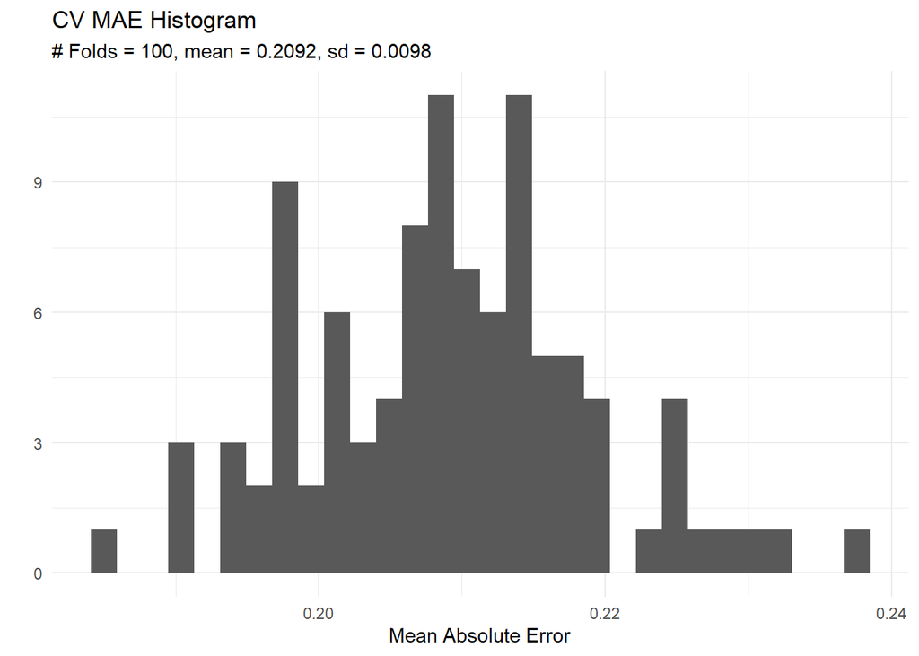

```r
inputdf.cv <- trainControl(method = 'cv', number = 100)


model.cv <-
  train(lnprice ~ ., data = inputdf %>% select(-price, -musaID),
        method = "lm", trControl = inputdf.cv, na.action = na.pass)



ggplot(model.cv$resample)+
  geom_histogram(aes(x = MAE))+
  theme_minimal()+
  labs(x = 'Mean Absolute Error', y='', title = 'CV MAE Histogram',
       subtitle = paste('# Folds = 100, mean = ',round(mean(model.cv$resample$MAE),4), ', sd = ', round(sd(model.cv$resample$MAE),4), sep = ''))
```

### Accuracy of predictions by home sale price (predicted sale price vs. actual sale price)

This scatterplot shows our predicted home values vs actual home values. This indicates the relationship between our predict home sales price to the actual home sale price to show how reliable our predictions are. Points nearest to the blue line indicate that our prediction is good. Points further away indicate that our prediction is bad (unreliable).

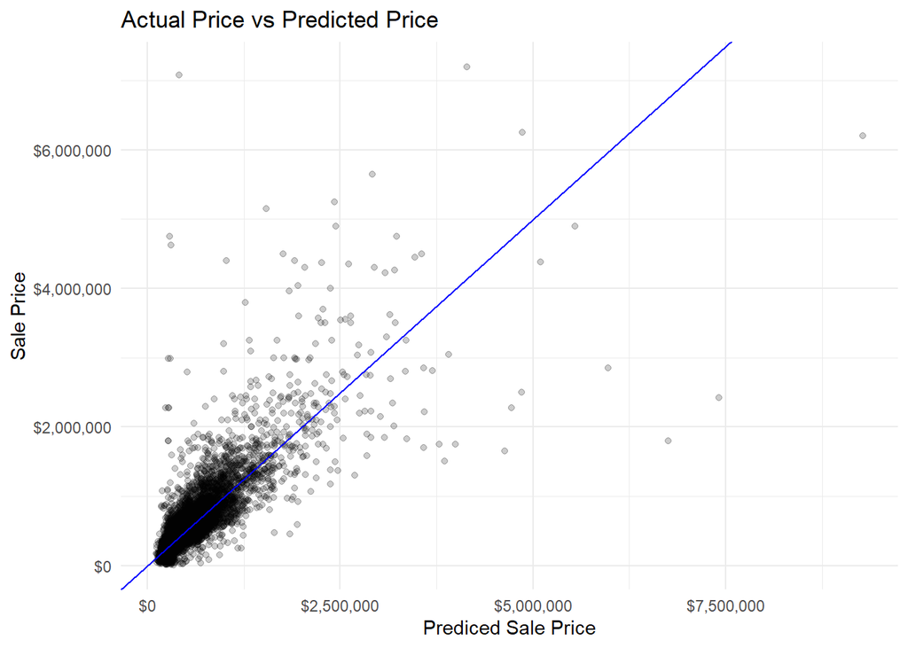

```r
ggplot(inputdf.test)+
  geom_point(aes(y= exp(lnprice), x = exp(SalePrice.Predict)), alpha = .2)+
  geom_abline(slope = 1, color = 'blue')+
  theme_minimal()+
  scale_y_continuous(labels = scales::dollar_format())+
  scale_x_continuous(labels = scales::dollar_format())+
  labs(y = 'Sale Price', x = 'Prediced Sale Price', title = 'Actual Price vs Predicted Price')
```

#Map of residuals The map shows clustering of over and under predictions. We see in the wedge mentioned before that home prices are under predicted while in more moderately priced areas they are over predicted. Our model does not include a spatial lag so we are not accounting for nearby home prices in the prediction of home price.

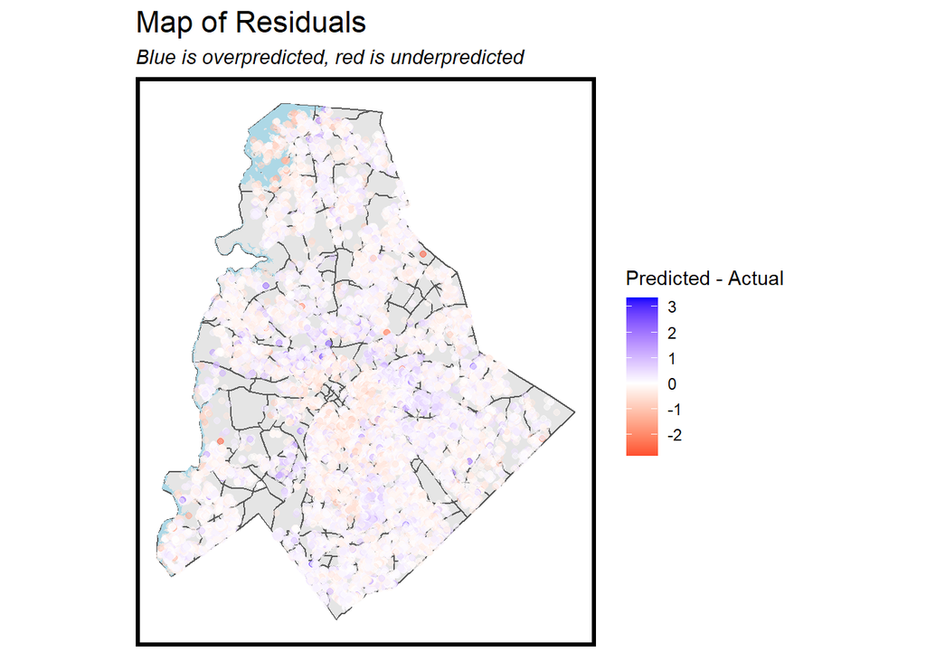

```r
inputdf.test.sf <- left_join(inputdf.test, homesales %>% select(musaID)) %>% st_as_sf()


ggplot(inputdf.test.sf)+
  geom_sf(data = char.census)+
  geom_sf(data = water %>% filter(AWATER > 500000), fill = 'lightblue',color = NA)+
  geom_sf(aes(color = SalePrice.Error), alpha = .5)+
  scale_colour_gradient2(low = 'red',mid = 'white', high = 'blue')+
  mapTheme()+
  labs(title = 'Map of Residuals', color = 'Predicted - Actual', subtitle = 'Blue is overpredicted, red is underpredicted')
```

### Spatial lag and Moran’s I

Since there is a positive relationship between the price error and the spatial lag of the price error that means there is spatial auto-correlation for the error. This is also seen in the Moran’s I histogram below where the observed Moran’s I is way out of range of what would normally be seen if error was randomized.

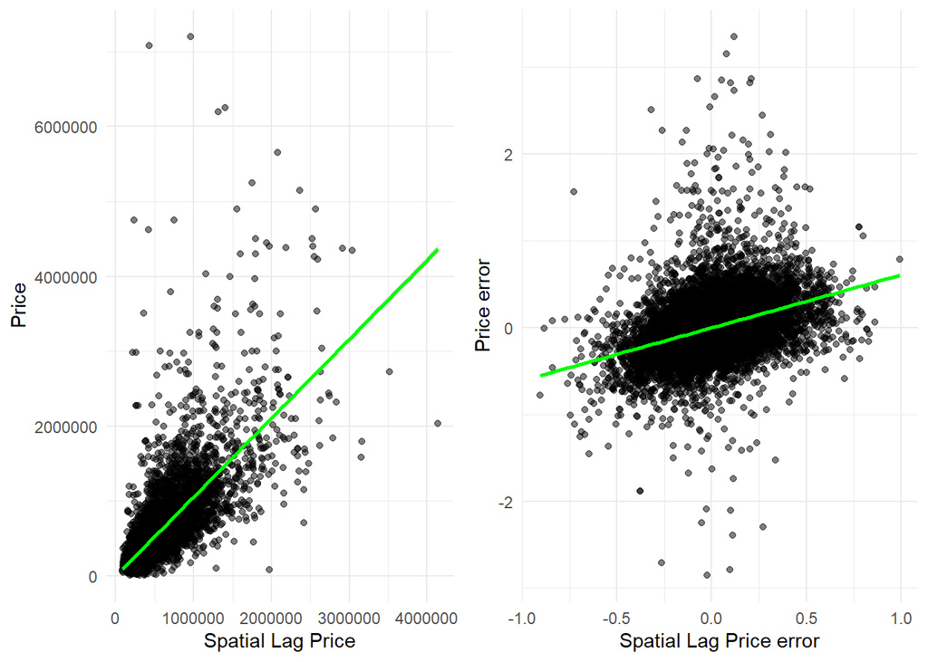

```r
coords <- st_coordinates(inputdf.test.sf)

neighborList <- knn2nb(knearneigh(coords, 5))

spatialWeights <- nb2listw(neighborList, style="W")


inputdf.test.sf <- inputdf.test.sf %>%
  mutate(lagPriceError = lag.listw(spatialWeights, SalePrice.Error),#error lag
         laglnPrice = lag.listw(spatialWeights, lnprice))

k1 <- ggplot(inputdf.test.sf, aes(exp(laglnPrice), exp(lnprice)))+
  geom_point(alpha = .5)+
  geom_smooth(method = 'lm', color = 'green')+
  theme_minimal()+
  labs(y='Price', x = 'Spatial Lag Price')

k2 <- ggplot(inputdf.test.sf, aes(lagPriceError, SalePrice.Error))+
  geom_point(alpha = .5)+
  geom_smooth(method = 'lm', color = 'green')+
  theme_minimal()+
  labs(y='Price error', x = 'Spatial Lag Price error')

cowplot::plot_grid(k1,k2)
```

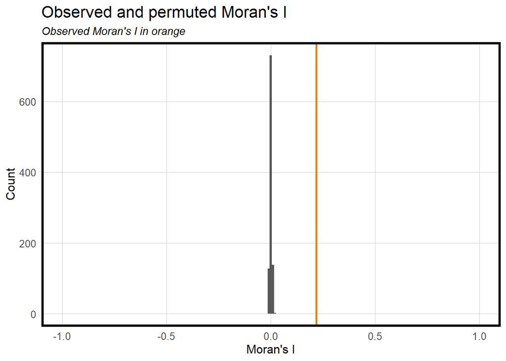

```r
moranTest <- moran.mc(inputdf.test.sf$SalePrice.Error,
                      spatialWeights, nsim = 999)

ggplot(as.data.frame(moranTest$res[c(1:999)]), aes(moranTest$res[c(1:999)])) +
  geom_histogram(binwidth = 0.01) +
  geom_vline(aes(xintercept = moranTest$statistic), colour = "#FA7800",size=1) +
  scale_x_continuous(limits = c(-1, 1)) +
  labs(title="Observed and permuted Moran's I",
       subtitle= "Observed Moran's I in orange",
       x="Moran's I",
       y="Count") +
  plotTheme()
```

### Challenge Set

The 100 properties from the challenge set are evenly spread out across Mecklenburg County. Therefore they have no clear pattern. We used our model to predict on these 100 properties to further demonstrate our models generalizability.

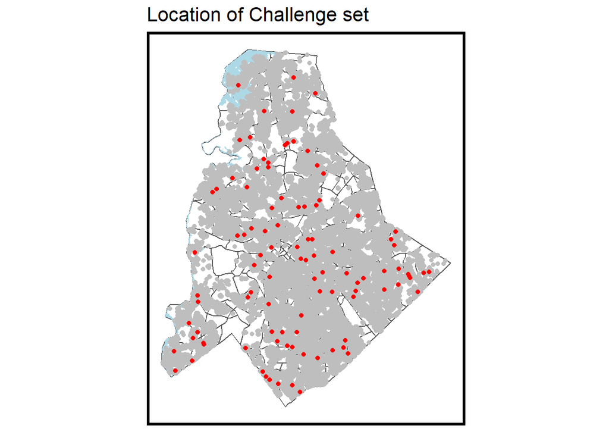

```r
ggplot()+
  geom_sf(data = char.census, fill = NA)+
  geom_sf(data = water %>% filter(AWATER > 500000), fill = 'lightblue',color = NA)+
  geom_sf(data = homesales %>% filter(toPredict == 'MODELLING'),
          color = 'grey')+
  geom_sf(data = homesales %>% filter(toPredict == 'CHALLENGE'),
          color = 'red')+
  mapTheme()+
  labs(title = 'Location of Challenge set')
```

### Mean Absolute percentage error (MAPE) by neighborhood.

Our model is more accurate in the darker shaded neighborhoods and less accurate in the lighter shaded neighborhoods. The darker neighborhoods indicate that the Median Percent Era (MAPE) is off by a small margin compared to the lighter areas. Thus determining the accuracy of predicted home value in comparison to the actual price.

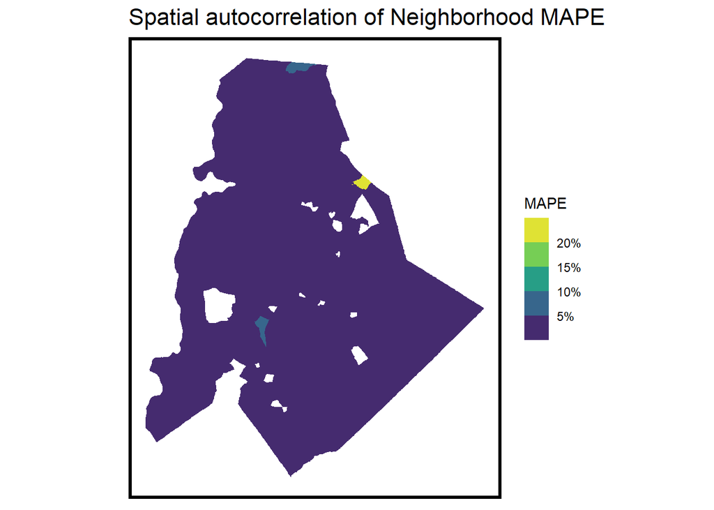

```r
inputdf.test.sf <- st_join(inputdf.test.sf, homesales %>% select(musaID, npa))

nbhoodmape <- inputdf.test.sf %>% st_drop_geometry() %>%
  group_by(npa) %>%
  summarize(meanerror = mean(SalePrice.APE),
            meanprice = mean(price)) %>% left_join(nbhoods) %>% st_as_sf()

ggplot(nbhoodmape)+
  geom_sf(aes(fill = meanerror), color = NA)+
  scale_fill_viridis_b(labels = scales::percent)+
  mapTheme()+
  labs(title = 'Spatial autocorrelation of Neighborhood MAPE', fill = 'MAPE')
```

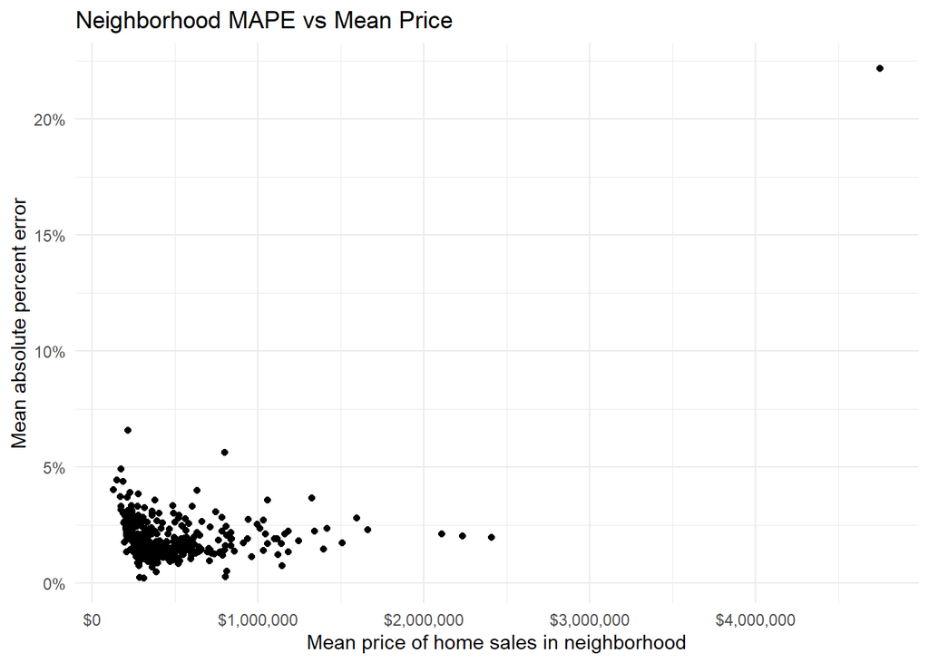

```r
ggplot(nbhoodmape)+
  geom_point(aes(x = meanprice, y = meanerror))+
  theme_minimal()+
  scale_y_continuous(labels = scales::percent)+

  labs(title = 'Neighborhood MAPE vs Mean Price', y = 'Mean absolute percent error', x = 'Mean price of home sales in neighborhood')+
  scale_x_continuous(labels = scales::dollar_format())
```

## Demograpics of Mecklenburg County Housing Market

If we look at the map below we are able to see which areas are majority-white people populations and which areas are majority non-white areas. From our analysis we can noticeable visualize that the wealthy areas and more expensive homes are occupied by majority white populations. On the flip side of that we can see that the the central belt has moderate to low priced homes and they are occupied by majority non-white populations.

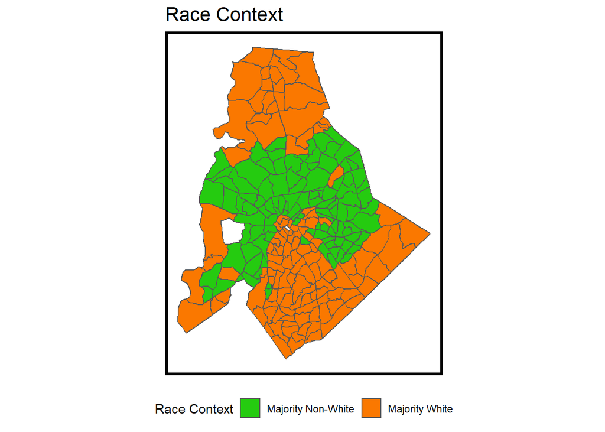

```r
censusrace <-
  get_acs(geography = "tract", variables = c("B01001_001E","B01001A_001E"),
          year = 2017, state='North Carolina', county='Mecklenburg', geometry=T, output = "wide") %>%
  st_transform(st_crs(homesales))  %>%
  rename(TotalPop = B01001_001E,
         NumberWhites = B01001A_001E) %>%
  mutate(percentWhite = NumberWhites / TotalPop,
         raceContext = ifelse(percentWhite > .5, "Majority White", "Majority Non-White"))

ggplot()+
  geom_sf(data = na.omit(censusrace), aes(fill = raceContext)) +
  scale_fill_manual(values = c("#25CB10", "#FA7800"), name="Race Context") +
  labs(title = "Race Context") +
  mapTheme() + theme(legend.position="bottom")
```

```r
inputdf.test.sf <- st_join(inputdf.test.sf, censusrace)
```

```r
racetab <- inputdf.test.sf %>% st_drop_geometry() %>%  group_by(raceContext) %>%
  summarize(MAPE = scales::percent(mean(SalePrice.AbsError, na.rm =T)))

racetab[1:2,] %>% gt() %>%
  gt::cols_label(raceContext = 'Census tract race context' )
```

| Census tract race context | MAPE |
| --- | --- |
| Majority Non-White | 22% |
| Majority White | 20% |

## Conclusion

Our model is effective to some degree, but with more time to dedicate to feature engineering the accuracy could be increased. It is interesting to see the impact that the school district has on the price of a home. Other notable predictors like the exterior wall and building grade were important to the model as well. Although our model falls short on the accuracy of the individual price prediction of homes, it is effective in painting the broad picture of the housing market in Mecklenburg County. We can clearly and accurately distinguish the wealthiest areas from the lower priced areas.

Typically individual(s) seeking to buy a home know what income bracket they fall under. Specificity of individual house price is somewhat irrelevant in the sense that it doesn’t keep in to account which home is actually on the market. Therefore the value of a home isn’t really known until it is on the market and there are many unpredictable factors like the speed someone wants to sell there home for, or whether it is a recession or housing bubble, and/or how long a home has been on the market. In a nutshell each home sale price is circumstantial.

### Recommendation

Our model is very useful and effective at providing a broad overview of the housing market in Mecklenburg County. As mentioned in our discussion our model can confidently give a potential buyer an accurate overview of where prices of homes are high or low. However our model falls short in it’s specificity, it cannot accurately predict the actual home value because of lack of data on previous home sale history and sub-optimal feature engineering. For this reason we wouldn’t recommend our model to Zillow because Zillow’s platform enables homebuyers to have accurate knowledge on property value on which they can act upon directly. Our model could only inform a potential buyer on which neighborhoods are desirable or highly valued. They would still need to undergo another process to find the correct estimates.